# R Notebook

Dataset:

```r
#Load the two data set
library(dplyr)
library(readr)
```

```r
library(ggplot2)
library(tibble)
library(cluster)
library(factoextra)
library(dendextend)
library(circlize)
library(tidyverse)
library(ggrepel)
odi_info <- read_csv("C:/Users/vibha/OneDrive/Desktop/SA/Project/ODI_Match_info.csv")
#Data cleaning and exploration

#seaon cleaning
odi_info$season <- ifelse(grepl("^\\d{4}$", odi_info$season),
                          paste(odi_info$season, as.numeric(odi_info$season) + 1, sep = "/"),
                          odi_info$season)
print(unique(odi_info$season))
```

```
##  [1] "2023/24" "2022/23" "2021/22" "2020/21" "2019/20" "2018/19" "2017/18"
##  [8] "2016/17" "2015/16" "2014/15" "2013/14" "2012/13" "2011/12" "2010/11"
## [15] "2009/10" "2008/09" "2007/08" "2006/07" "2005/06" "2004/05" "2003/04"
## [22] "2002/03"
```

```r
head(odi_info)
```

| id | season | city | date | team1 | team2 | toss_winner | toss_decision | result | dl_applied | winner | win_by_runs | win_by_wickets | player_of_match | venue | umpire1 | umpire2 | umpire3 |
| --- | --- | --- | --- | --- | --- | --- | --- | --- | --- | --- | --- | --- | --- | --- | --- | --- | --- |
| 1389389 | 2023/24 | Indore | 24-09-2023 | India | Australia | Australia | field | D/L | 1 | India | 99 | 0 | SS Iyer | Holkar Cricket Stadium, Indore | J Madanagopal | HDPK Dharmasena | KN Ananthapadmanabhan |
| 1336129 | 2023/24 | Nottingham | 23-09-2023 | England | Ireland | Ireland | field | normal | 0 | England | 48 | 0 | WG Jacks | Trent Bridge, Nottingham | DJ Millns | RJ Tucker | PR Reiffel |
| 1395701 | 2023/24 | Dhaka | 23-09-2023 | New Zealand | Bangladesh | New Zealand | bat | normal | 0 | New Zealand | 86 | 0 | IS Sodhi | Shere Bangla National Stadium, Mirpur | M Erasmus | Sharfuddoula | Nitin Menon |
| 1389388 | 2023/24 | Chandigarh | 22-09-2023 | Australia | India | India | field | normal | 0 | India | 0 | 5 | Mohammed Shami | Punjab Cricket Association IS Bindra Stadium, Mohali, Chandigarh | KN Ananthapadmanabhan | HDPK Dharmasena | J Madanagopal |
| 1395700 | 2023/24 | Dhaka | 21-09-2023 | New Zealand | Bangladesh | Bangladesh | field | normal | 0 | NA | 0 | 0 | NA | Shere Bangla National Stadium, Mirpur | Nitin Menon | Sharfuddoula | M Erasmus |
| 1388414 | 2023/24 | Colombo | 17-09-2023 | Sri Lanka | India | Sri Lanka | bat | normal | 0 | India | 0 | 10 | Mohammed Siraj | R Premadasa Stadium, Colombo | Ahmed Shah Pakteen | RK Illingworth | CB Gaffaney |

```r
summary(odi_info)
```

```
##        id             season              city               date
##  Min.   :  64814   Length:2379        Length:2379        Length:2379
##  1st Qu.: 335350   Class :character   Class :character   Class :character
##  Median : 649095   Mode  :character   Mode  :character   Mode  :character
##  Mean   : 711435
##  3rd Qu.:1144488
##  Max.   :1395701
##     team1              team2           toss_winner        toss_decision
##  Length:2379        Length:2379        Length:2379        Length:2379
##  Class :character   Class :character   Class :character   Class :character
##  Mode  :character   Mode  :character   Mode  :character   Mode  :character
##
##
##
##     result            dl_applied         winner           win_by_runs
##  Length:2379        Min.   :0.00000   Length:2379        Min.   :  0.00
##  Class :character   1st Qu.:0.00000   Class :character   1st Qu.:  0.00
##  Mode  :character   Median :0.00000   Mode  :character   Median :  0.00
##                     Mean   :0.08449                      Mean   : 34.68
##                     3rd Qu.:0.00000                      3rd Qu.: 58.00
##                     Max.   :1.00000                      Max.   :317.00
##  win_by_wickets   player_of_match       venue             umpire1
##  Min.   : 0.000   Length:2379        Length:2379        Length:2379
##  1st Qu.: 0.000   Class :character   Class :character   Class :character
##  Median : 0.000   Mode  :character   Mode  :character   Mode  :character
##  Mean   : 2.751
##  3rd Qu.: 6.000
##  Max.   :10.000
##    umpire2            umpire3
##  Length:2379        Length:2379
##  Class :character   Class :character
##  Mode  :character   Mode  :character
##
##
##
```

Visualizations: VisualS 1 & 2 for match information dataset: 1. Number of Matches per season 2. Wins per Team over season

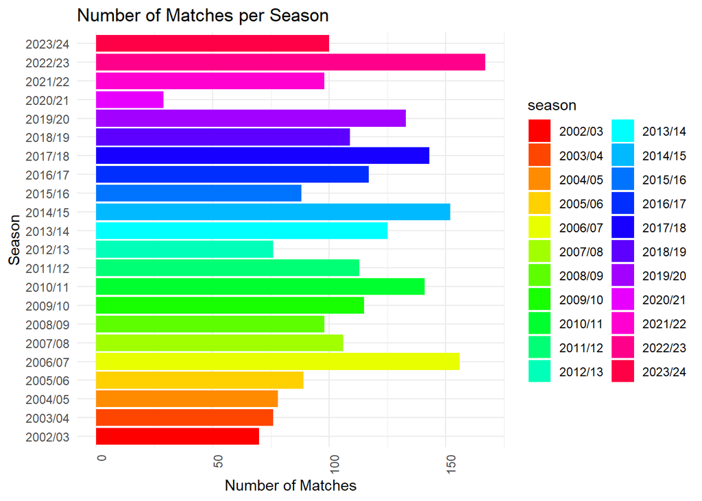

```r
#1. Number of Matches per season
 #assigning colors
my_colors <- rainbow(length(unique(odi_info$season)))

ggplot(odi_info, aes(x = season, fill = season)) +
  geom_bar() +
  labs(
    title = "Number of Matches per Season",
    x = "Season",
    y = "Number of Matches"
  ) +
  coord_flip()+
  scale_fill_manual(values = my_colors) +
  theme_minimal() +
  theme(axis.text.x = element_text(angle = 90, hjust = 1))
```

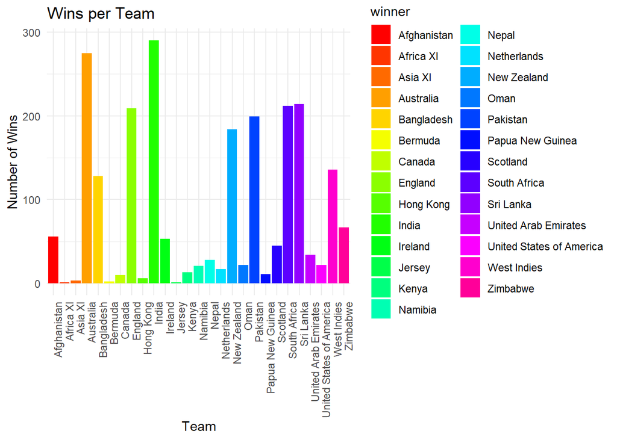

```r
#2. Wins per Team over season
# Filter out NA values from the winner column
odi_info_final <- odi_info[!is.na(odi_info$winner), ]

# Create the bar plot
ggplot(odi_info_final, aes(x = winner, fill = winner)) +
  geom_bar() +
  labs(
    title = 'Wins per Team',
    x = 'Team',
    y = 'Number of Wins'
  ) +
  scale_fill_manual(values = rainbow(length(unique(odi_info_final$winner)), end = 0.9)) +
  theme_minimal() +
  theme(axis.text.x = element_text(angle = 90, hjust = 1))
```

1b. Wins per Team Over All Seasons: Illustrates the distribution of wins among teams across seasons, identifying dominant teams and those with minimal wins.

Visual 3: Toss Decision - Bat or field Bar Chart

```r
toss_Decision <- table(odi_info$toss_decision)
toss_Decision
```

```
##
##   bat field
##  1218  1161
```

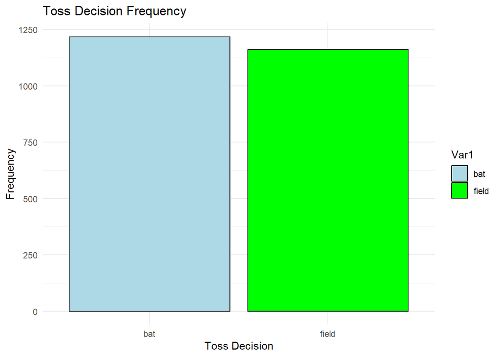

```r
ggplot(data = as.data.frame(toss_Decision), aes(x = Var1, y = Freq, fill = Var1)) +
  geom_bar(stat = "identity", color = "black") +
  ggtitle("Toss Decision Frequency") +
  xlab("Toss Decision") +
  ylab("Frequency") +
  scale_fill_manual(values = c("bat" = "lightblue", "field" = "green")) +
  theme_minimal()
```

Insights: In this bar chart, the numbers 1218 and 1161 represent the frequency of toss decisions made by teams in cricket matches. The ‘bat’ category indicates the decision to bat first after winning the toss, while ‘field’ signifies the decision to field first.

Visual 4: Stacked bar chart for Winnig by Runs or Wicket

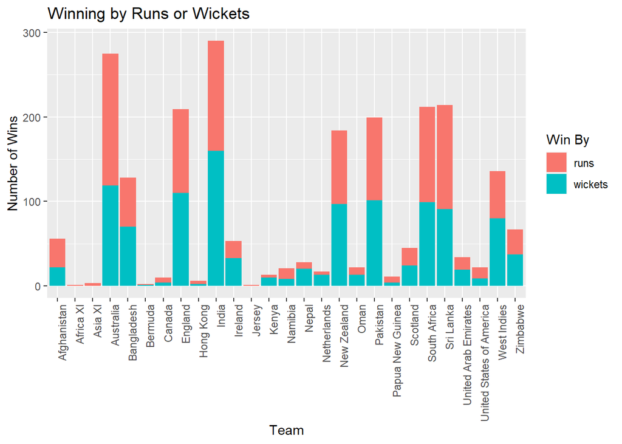

```r
#  new column 'win_by' that records whether the match was won by runs or wickets
odi_info$win_by <- ifelse(odi_info$win_by_runs > 0, 'runs', 'wickets')

# stacked bar plot for the number of wins by runs or wickets per team
win_counts <- table(odi_info$winner, odi_info$win_by)

win_counts_df <- as.data.frame.table(win_counts)

# Plot the data
ggplot(win_counts_df, aes(x = Var1, y = Freq, fill = Var2)) +
  geom_bar(stat = 'identity') +
  labs(x = 'Team', y = 'Number of Wins', fill = 'Win By') +
  theme(axis.text.x = element_text(angle = 90, hjust = 1)) +
  ggtitle('Winning by Runs or Wickets')
```

Insights: The visual represent teams’ winning strategies, with orange bars indicating matches won by runs (batting first) and blue bars representing matches won by wickets (batting second). It underscores the diversity in team approaches, with factors like team composition, pitch conditions, and opposition strength influencing their preferred strategie

Visual 5: Top 3 teams performance over last 10 years

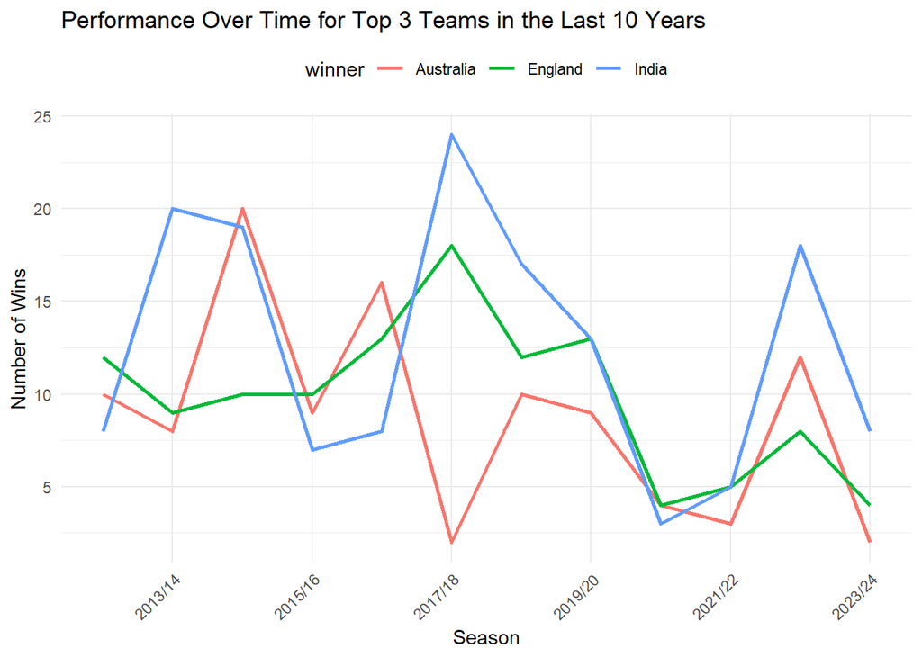

```r
# top 3 teams
top_teams <- c("India", "England", "Australia")
top_teams_wins <- subset(odi_info, winner %in% top_teams)

# Filter data for the last 10 years
last_10_years <- c("2012/13", "2013/14", "2014/15", "2015/16", "2016/17", "2017/18", "2018/19", "2019/20", "2020/21", "2021/22", "2022/23", "2023/24")
top_teams_wins <- top_teams_wins %>% filter(season %in% last_10_years)

# line plot
ggplot(data = top_teams_wins, aes(x = season, color = winner)) +
  geom_line(stat = "count", aes(group = winner), size = 1) +
  labs(
    title = "Performance Over Time for Top 3 Teams in the Last 10 Years",
    x = "Season",
    y = "Number of Wins"
  ) +
  theme_minimal() +
  theme(legend.position = "top", axis.text.x = element_text(angle = 45, hjust = 1)) +
  scale_x_discrete(breaks = unique(top_teams_wins$season)[seq(1, length(unique(top_teams_wins$season)), by = 2)])
```

Visual 7: Let’s run a correlation model

```r
library(corrplot)
numeric_data <- odi_info[sapply(odi_info, is.numeric)]

# Compute correlation matrix
correlation_matrix <- cor(numeric_data)
correlation_matrix
```

```
##                          id   dl_applied  win_by_runs win_by_wickets
## id              1.000000000 -0.007344581  0.006960059    -0.02862123
## dl_applied     -0.007344581  1.000000000 -0.030401806    -0.01722247
## win_by_runs     0.006960059 -0.030401806  1.000000000    -0.54580459
## win_by_wickets -0.028621230 -0.017222470 -0.545804589     1.00000000
```

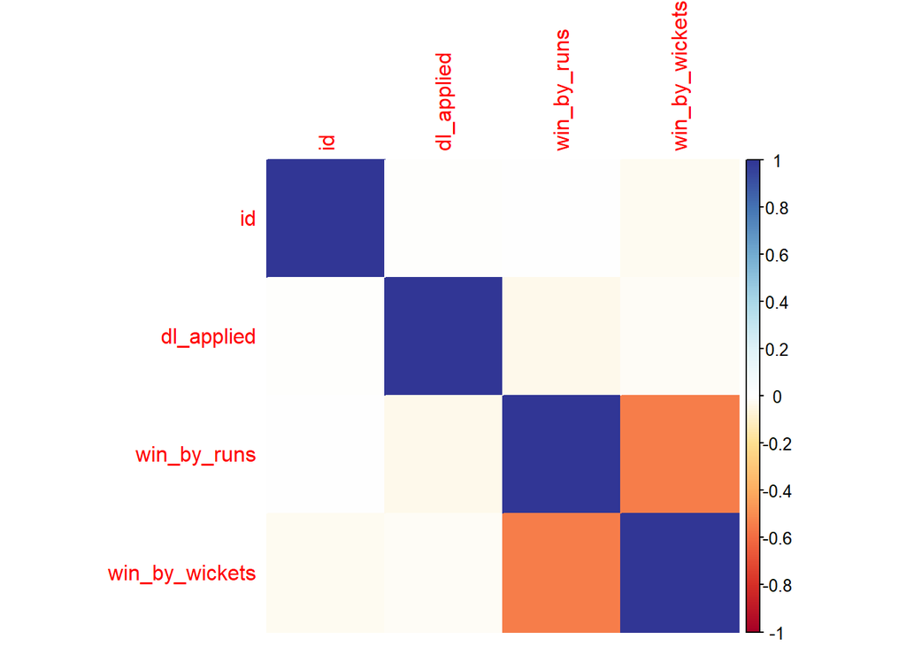

```r
corrplot(correlation_matrix, method = "color", col = COL2("RdYlBu"))
```

```r
#My heatmap is really large - not sure how to adjust it
```

Lets dive into the second dataset and do few summary stats for 2023-2024 season

```r
library(readr)
odi_data <- read_csv("C:/Users/vibha/OneDrive/Desktop/SA/Project/ODI_Match_Data.csv")
# Filter for the 2023 and 2023/24 seasons
odi_data_2023 <- odi_data[odi_data$season == "2023"| odi_data$season == "2023/24", ]
odi_data_2023 <-odi_data_2023[, c(-20,-21,-22,-23)]
head(odi_data_2023)
```

| match_id | season | start_date | venue | innings | ball | batting_team | bowling_team | striker | non_striker | bowler | runs_off_bat | extras | wides | noballs | byes | legbyes | penalty | wicket_type |
| --- | --- | --- | --- | --- | --- | --- | --- | --- | --- | --- | --- | --- | --- | --- | --- | --- | --- | --- |
| 1389389 | 2023/24 | 24-09-2023 | Holkar Cricket Stadium, Indore | 1 | 0.1 | India | Australia | RD Gaikwad | Shubman Gill | SH Johnson | 4 | 0 | NA | NA | NA | NA | NA | NA |
| 1389389 | 2023/24 | 24-09-2023 | Holkar Cricket Stadium, Indore | 1 | 0.2 | India | Australia | RD Gaikwad | Shubman Gill | SH Johnson | 0 | 0 | NA | NA | NA | NA | NA | NA |
| 1389389 | 2023/24 | 24-09-2023 | Holkar Cricket Stadium, Indore | 1 | 0.3 | India | Australia | RD Gaikwad | Shubman Gill | SH Johnson | 4 | 0 | NA | NA | NA | NA | NA | NA |
| 1389389 | 2023/24 | 24-09-2023 | Holkar Cricket Stadium, Indore | 1 | 0.4 | India | Australia | RD Gaikwad | Shubman Gill | SH Johnson | 0 | 0 | NA | NA | NA | NA | NA | NA |
| 1389389 | 2023/24 | 24-09-2023 | Holkar Cricket Stadium, Indore | 1 | 0.5 | India | Australia | RD Gaikwad | Shubman Gill | SH Johnson | 0 | 0 | NA | NA | NA | NA | NA | NA |
| 1389389 | 2023/24 | 24-09-2023 | Holkar Cricket Stadium, Indore | 1 | 0.6 | India | Australia | RD Gaikwad | Shubman Gill | SH Johnson | 0 | 5 | 5 | NA | NA | NA | NA | NA |

```r
summary(odi_data_2023)
```

```
##     match_id          season           start_date           venue
##  Min.   :1336052   Length:52891       Length:52891       Length:52891
##  1st Qu.:1365105   Class :character   Class :character   Class :character
##  Median :1377751   Mode  :character   Mode  :character   Mode  :character
##  Mean   :1373005
##  3rd Qu.:1377775
##  Max.   :1395701
##
##     innings           ball       batting_team       bowling_team
##  Min.   :1.000   Min.   : 0.10   Length:52891       Length:52891
##  1st Qu.:1.000   1st Qu.:10.50   Class :character   Class :character
##  Median :1.000   Median :21.60   Mode  :character   Mode  :character
##  Mean   :1.451   Mean   :22.46
##  3rd Qu.:2.000   3rd Qu.:33.60
##  Max.   :4.000   Max.   :49.80
##
##    striker          non_striker           bowler           runs_off_bat
##  Length:52891       Length:52891       Length:52891       Min.   :0.0000
##  Class :character   Class :character   Class :character   1st Qu.:0.0000
##  Mode  :character   Mode  :character   Mode  :character   Median :0.0000
##                                                           Mean   :0.8383
##                                                           3rd Qu.:1.0000
##                                                           Max.   :6.0000
##
##      extras           wides          noballs           byes
##  Min.   :0.0000   Min.   :1.00    Min.   :1       Min.   :1.00
##  1st Qu.:0.0000   1st Qu.:1.00    1st Qu.:1       1st Qu.:1.00
##  Median :0.0000   Median :1.00    Median :1       Median :1.00
##  Mean   :0.0491   Mean   :1.24    Mean   :1       Mean   :1.95
##  3rd Qu.:0.0000   3rd Qu.:1.00    3rd Qu.:1       3rd Qu.:4.00
##  Max.   :5.0000   Max.   :5.00    Max.   :1       Max.   :4.00
##                   NA's   :51613   NA's   :52763   NA's   :52788
##     legbyes      penalty        wicket_type
##  Min.   :1.00    Mode:logical   Length:52891
##  1st Qu.:1.00    NA's:52891     Class :character
##  Median :1.00                   Mode  :character
##  Mean   :1.39
##  3rd Qu.:1.00
##  Max.   :4.00
##  NA's   :52411
```

Visual 7: Bowling and Batting average

```r
#checking all the countries
unique(odi_data_2023$batting_team)
```

```
##  [1] "India"                    "Australia"
##  [3] "England"                  "Ireland"
##  [5] "New Zealand"              "Bangladesh"
##  [7] "South Africa"             "Sri Lanka"
##  [9] "Pakistan"                 "Afghanistan"
## [11] "Nepal"                    "West Indies"
## [13] "Netherlands"              "Scotland"
## [15] "United Arab Emirates"     "United States of America"
## [17] "Oman"                     "Zimbabwe"
## [19] "Jersey"                   "Canada"
## [21] "Papua New Guinea"         "Namibia"
```

```r
team_stats <- odi_data_2023 %>%
  group_by(batting_team) %>%
  summarize(
    batting_avg = mean(runs_off_bat),
    bowling_avg = mean(ifelse(!is.na(wicket_type), 1, 0))
  )

team_stats
```

| batting_team | batting_avg | bowling_avg |
| --- | --- | --- |
| Afghanistan | 0.7776938 | 0.03402647 |
| Australia | 1.0130952 | 0.03928571 |
| Bangladesh | 0.7744825 | 0.03120173 |
| Canada | 0.6626917 | 0.03236797 |
| England | 1.0285914 | 0.02789400 |
| India | 0.9265033 | 0.02301411 |
| Ireland | 0.9140445 | 0.02647736 |
| Jersey | 0.7544605 | 0.02803738 |
| Namibia | 0.7862524 | 0.02919021 |
| Nepal | 0.7451420 | 0.02952167 |

[output cut: 12 more lines]